# BCHC Policy Review PN1: Simulate Data

Ran Li

8/03/2021

**Broad goal of this report is describe the simulation of data to be used in dashboard prototype**

# Categories of Policy/Outcomes to simulate

## Policies

I reorganized the original policies by adding some directional policy names, policy groups and prior beliefs. The Prior beliefs column is meant to refelct our prior assumptions to do some data simulation: Positive means the policy in the ‘Policy Short’ column has a positive effect on the health outcome; Negative means the associated policy has a negative effect on the health outcome. The last column (Z-score) is just an assumed effect size used for the simulation.

| Policy Group | Policy | Policy Short | Prior Belief effect on health Outcomes | Prior Z Score |
| --- | --- | --- | --- | --- |
| Education and Childcare | Policies related to childcare (e.g., access, affordability, etc.) | Increased Childcare | Positive | 0.7 |
| Income | Employment, unemployment, and labor policies | Inclusive labor policies | Positive | 0.9 |
| Housing | Housing policies (e.g., mortgage access and assistance, property tax policies, eviction and displacement protection, rent protection, etc.) | Benefitial Housing Policy | Positive | 0.9 |
| Income | Income inequity and poverty | Equity based policies | Positive | 0.8 |
| Education and Childcare | Investments in public schooling | Public schooling Investments | Positive | 0.9 |
| Insurance | Insurance access (public or private) | Increased Isurance access | Positive | 0.8 |
| Income | Paid leave (e.g., family leave, medical/sick leave) | Paid Leave | Positive | 0.9 |
| Discrimination | Policies related to racial discrimination (e.g., Jim Crow, redlining, etc.) | Racial discrimination | Negative | -0.9 |
| Housing | Policies related to community investment (or disinvestment) and neighborhood advantage | Community Investment | Positive | 0.9 |
| Income | Policies related to wages and economic inclusion (e.g., living wages, wage increases, Universal Basic Income, etc.) | Inclusive economic policy | Positive | 0.9 |

[output cut: 5 more lines]

## Outcomes

Some outcomes were renamed to be shorter. No major changes.

| Outcome | Outcome Short |
| --- | --- |
| Chronic diseases | Chronic diseases |
| Homicide | Homicide |
| Infant Mortality | Infant Mortality |
| Injuries (Unintentional) | Injuries (Unintentional) |
| Life Expectancy / Premature Mortality | Life Expectancy |
| Mental health conditions | Mental health conditions |
| Poisoning / Overdoses | Poisoning / Overdoses |
| Sexually transmitted infections | Sexually transmitted infections |
| Substance use disorders | Substance use disorders |
| Suicide | Suicide |

# Data Simulation

## Data Format

The input for this data tool should contain the at least following columns:

- paper title
- policy (exposure)
- Health Outcome
- Link: Negative (when policy results in worse health outcome) or Positive (when policy results in better health outcome)

| Title | Policy | Outcome | Link |
| --- | --- | --- | --- |
| Jim Crow and estrogen-receptor-negative breast cancer: US-born black and white non-Hispanic women, 1992–2012 | Policies related to racial discrimination (e.g., Jim Crow, redlining, etc.) | Chronic diseases | Negative |
| The Unique Impact of Abolition of Jim Crow Laws on Reducing Inequities in Infant Death Rates and Implications for Choice of Comparison Groups in Analyzing Societal Determinants of Health | Policies related to racial discrimination (e.g., Jim Crow, redlining, etc.) | Infant Mortality | Negative |
| Jim Crow and Premature Mortality Among the US Black and White Population, 1960–2009 | Policies related to racial discrimination (e.g., Jim Crow, redlining, etc.) | Life Expectancy / Premature Mortality | Negative |

## Simulate quantity and priors

We will want to simulate data in the format above. With several parameters that each policy/outcome link should have between 0 - 10 papers and the proportion of the positive/negative links among the policy/outcomes should approximate the prior assumptions in our Policies table.

For each policy/outcome pair simulate the number of papers available (0 - 10) using binomial distribution, then approximate the prior of each policy into each policy/outcome pair using normal distribution.

```r
### For each policy/outcome pair simulate the number of papers available (0 - 10) with approximate prior effect
df_sim_raw = df_policies %>%
  select(policy =`Policy Short`,
         prior = `Prior Z Score`) %>%
  mutate(prior_dir = ifelse(prior>=0,1,-1),
         prior = abs(prior))
set.seed(123)
df_n_paper = df_sim_raw %>%
  mutate(policyGrouper = policy) %>%
  group_by(policyGrouper) %>%
  group_modify(~{
    df_tmp = .x
    df_n_papers_tmp = tibble(
      policy = df_tmp$policy,
      outcome = outcomesAll,
      nPapers =  rbinom(length(outcomesAll),
                        10,0.15),
      prior = rnorm(length(outcomesAll),
                    0.8,
                    0.2) %>%
        round(4) ,
      prior_dir = df_tmp$prior_dir) %>%
      mutate(prior =  ifelse(prior>1,1,prior))
    df_n_papers_tmp
  }) %>%
  ungroup() %>%
  select(-contains('Grouper'))
reactable(df_n_paper)
```

| policy | outcome | nPapers | prior | prior_dir |
| --- | --- | --- | --- | --- |
| Benefitial Housing Policy | Chronic diseases | 1 | 1 | 1 |
| Benefitial Housing Policy | Homicide | 2 | 0.8922 | 1 |
| Benefitial Housing Policy | Infant Mortality | 1 | 0.547 | 1 |
| Benefitial Housing Policy | Injuries (Unintentional) | 3 | 0.6626 | 1 |
| Benefitial Housing Policy | Life Expectancy / Premature Mortality | 3 | 0.7109 | 1 |
| Benefitial Housing Policy | Mental health conditions | 0 | 1 | 1 |
| Benefitial Housing Policy | Poisoning / Overdoses | 1 | 0.872 | 1 |
| Benefitial Housing Policy | Sexually transmitted infections | 3 | 0.8802 | 1 |
| Benefitial Housing Policy | Substance use disorders | 2 | 0.8221 | 1 |
| Benefitial Housing Policy | Suicide | 1 | 0.6888 | 1 |

[output cut: 140 more lines]

So for each policy/outcome pair we now have simulated number of papers reviewed and effect size of each pair. The next step is to simulate the actual papers them selves.

| Title | Policy | Outcome | Link |
| --- | --- | --- | --- |
| HmPsw2WtYSxSgZ6 | Benefitial Housing Policy | Chronic diseases | Positive |
| 2KxtgdzehXaH9xt | Benefitial Housing Policy | Homicide | Negative |
| gn1TlDJE8PPM98E | Benefitial Housing Policy | Homicide | Positive |
| Gr2Rn7YC7ktNf5N | Benefitial Housing Policy | Infant Mortality | Positive |
| oonRkdi0TDNbL6F | Benefitial Housing Policy | Injuries (Unintentional) | Positive |
| fPm6QztsA8eLeJB | Benefitial Housing Policy | Injuries (Unintentional) | Negative |
| m5SVbKUxTtubP9v | Benefitial Housing Policy | Injuries (Unintentional) | Positive |
| i8YxaPeJJDMz958 | Benefitial Housing Policy | Life Expectancy / Premature Mortality | Positive |
| gctfjWeomyRJP0B | Benefitial Housing Policy | Life Expectancy / Premature Mortality | Positive |
| qEE4FjqUOF6OZDR | Benefitial Housing Policy | Life Expectancy / Premature Mortality | Negative |

[output cut: 213 more lines]

Great now we have a simulated dataset. Lets do a summary table to make sure the results are as expected.

# Simulate Output Table

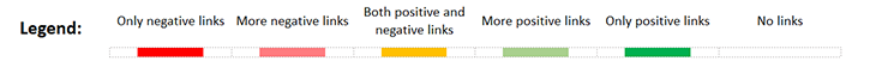

| Policy | Chronic diseases | Homicide | Infant Mortality | Injuries (Unintentional) | Sexually transmitted infections | Substance use disorders | Suicide |
| --- | --- | --- | --- | --- | --- | --- | --- |
| Benefitial Housing Policy | po | bo | po | ps | po | po | no |
| Community Investment | ps | po | bo | bo | no | po | po |
| Conservative Tax Policy | no | np | po | no | no | no | no |
| Decreased Voting Access | np | no | no | no | np | no | no |
| Equity based Built Environment policy | po | po | po | po | np | np | po |
| Equity based policies | po | po | po | po | po | po | po |
| Equity based Tax Policy | ps | po | po | po | po | po | ps |
| Inclusive economic policy | po | po | po | po | no | no | ps |
| Inclusive labor policies | bo | bo | np | bo | po | po | bo |
| Increased Childcare | ps | np | np | np | po | np | bo |

[output cut: 5 more lines]

```r
library(jsonlite)
json_sim = df_simulate_output %>% toJSON()
write(json_sim, file = "json_sim.json")
```